# Exploratory Data Analysis

```python
#import all the packages
import pandas as pd
import numpy as np
import matplotlib.pyplot as plt
import seaborn as sb
import glob
import os
```

## Gather Data

```python
#Append all the 2018 data in one master dataframe.
foldername ='2018_data'
all_files = glob.glob(os.path.join(foldername,'*.csv'))
df = pd.concat((pd.read_csv(f) for f in all_files), ignore_index = True)
```

```python
#Write above loaded data to master_data.csv file .
df.to_csv('master_data.csv', index=False)
```

```python
#load the dataset
df=pd.read_csv('master_data.csv')
```

## Access Data

```python
#Display the dataset
df.head()
```

|  | duration_sec | start_time | end_time | start_station_id | start_station_name | start_station_latitude | start_station_longitude | end_station_id | end_station_name | end_station_latitude | end_station_longitude | bike_id | user_type | bike_share_for_all_trip |
| --- | --- | --- | --- | --- | --- | --- | --- | --- | --- | --- | --- | --- | --- | --- |
| 0 | 75284 | 2018-01-31 22:52:35.2390 | 2018-02-01 19:47:19.8240 | 120.0 | Mission Dolores Park | 37.761420 | -122.426435 | 285.0 | Webster St at O'Farrell St | 37.783521 | -122.431158 | 2765 | Subscriber | No |
| 1 | 85422 | 2018-01-31 16:13:34.3510 | 2018-02-01 15:57:17.3100 | 15.0 | San Francisco Ferry Building (Harry Bridges Pl... | 37.795392 | -122.394203 | 15.0 | San Francisco Ferry Building (Harry Bridges Pl... | 37.795392 | -122.394203 | 2815 | Customer | No |
| 2 | 71576 | 2018-01-31 14:23:55.8890 | 2018-02-01 10:16:52.1160 | 304.0 | Jackson St at 5th St | 37.348759 | -121.894798 | 296.0 | 5th St at Virginia St | 37.325998 | -121.877120 | 3039 | Customer | No |
| 3 | 61076 | 2018-01-31 14:53:23.5620 | 2018-02-01 07:51:20.5000 | 75.0 | Market St at Franklin St | 37.773793 | -122.421239 | 47.0 | 4th St at Harrison St | 37.780955 | -122.399749 | 321 | Customer | No |
| 4 | 39966 | 2018-01-31 19:52:24.6670 | 2018-02-01 06:58:31.0530 | 74.0 | Laguna St at Hayes St | 37.776435 | -122.426244 | 19.0 | Post St at Kearny St | 37.788975 | -122.403452 | 617 | Subscriber | No |

```python
#Display no of rows and columns
df.shape
```

```
(1863721, 14)
```

```python
#print columns name
print(df.columns)
```

```
Index(['duration_sec', 'start_time', 'end_time', 'start_station_id',
       'start_station_name', 'start_station_latitude',
       'start_station_longitude', 'end_station_id', 'end_station_name',
       'end_station_latitude', 'end_station_longitude', 'bike_id', 'user_type',
       'bike_share_for_all_trip'],
      dtype='object')
```

```python
# View information of  DataFrame
df.info(null_counts=True)
```

```
<class 'pandas.core.frame.DataFrame'>
RangeIndex: 1863721 entries, 0 to 1863720
Data columns (total 14 columns):
duration_sec               1863721 non-null int64
start_time                 1863721 non-null object
end_time                   1863721 non-null object
start_station_id           1851950 non-null float64
start_station_name         1851950 non-null object
start_station_latitude     1863721 non-null float64
start_station_longitude    1863721 non-null float64
end_station_id             1851950 non-null float64
end_station_name           1851950 non-null object
end_station_latitude       1863721 non-null float64
end_station_longitude      1863721 non-null float64
bike_id                    1863721 non-null int64
user_type                  1863721 non-null object
bike_share_for_all_trip    1863721 non-null object
dtypes: float64(6), int64(2), object(6)
memory usage: 199.1+ MB
```

```python
#get descriptive statistics
df.describe()
```

|  | duration_sec | start_station_id | start_station_latitude | start_station_longitude | end_station_id | end_station_latitude | end_station_longitude | bike_id |
| --- | --- | --- | --- | --- | --- | --- | --- | --- |
| count | 1.863721e+06 | 1.851950e+06 | 1.863721e+06 | 1.863721e+06 | 1.851950e+06 | 1.863721e+06 | 1.863721e+06 | 1.863721e+06 |
| mean | 8.573026e+02 | 1.196744e+02 | 3.776678e+01 | -1.223492e+02 | 1.181730e+02 | 3.776690e+01 | -1.223487e+02 | 2.296851e+03 |
| std | 2.370379e+03 | 1.003976e+02 | 1.057689e-01 | 1.654634e-01 | 1.004403e+02 | 1.056483e-01 | 1.650597e-01 | 1.287733e+03 |
| min | 6.100000e+01 | 3.000000e+00 | 3.726331e+01 | -1.224737e+02 | 3.000000e+00 | 3.726331e+01 | -1.224737e+02 | 1.100000e+01 |
| 25% | 3.500000e+02 | 3.300000e+01 | 3.777106e+01 | -1.224114e+02 | 3.000000e+01 | 3.777106e+01 | -1.224094e+02 | 1.225000e+03 |
| 50% | 5.560000e+02 | 8.900000e+01 | 3.778107e+01 | -1.223974e+02 | 8.800000e+01 | 3.778127e+01 | -1.223971e+02 | 2.338000e+03 |
| 75% | 8.720000e+02 | 1.860000e+02 | 3.779625e+01 | -1.222865e+02 | 1.830000e+02 | 3.779728e+01 | -1.222894e+02 | 3.333000e+03 |
| max | 8.636600e+04 | 3.810000e+02 | 4.551000e+01 | -7.357000e+01 | 3.810000e+02 | 4.551000e+01 | -7.357000e+01 | 6.234000e+03 |

```python
#Check for duplicates rows
sum(df.duplicated())
```

```
0
```

```python
#Check the null records.
df.isnull().sum()
```

```
duration_sec                   0
start_time                     0
end_time                       0
start_station_id           11771
start_station_name         11771
start_station_latitude         0
start_station_longitude        0
end_station_id             11771
end_station_name           11771
end_station_latitude           0
end_station_longitude          0
bike_id                        0
user_type                      0
bike_share_for_all_trip        0
dtype: int64
```

### Quality Issues:

1. Change the datatype of start_time and end_time from object to datetime type.
2. A lot of missing values in start and end station id and station name.

### Tidiness issue:

1. Create new column of duration_min using duration_sec.
2. Using start_time column, extract the start_hour,start_day,start_month.

## Cleaning Data

```python
#Create copies of original DataFrames
df_clean = df.copy()
```

### Define

#### 1. Change the datatype of start_time and end_time from object to datetime type.

### Code

```python
#Change the datatype of start_time and end_time from object to datetime type.
df_clean['start_time']= pd.to_datetime(df_clean['start_time'])
df_clean['end_time']= pd.to_datetime(df_clean['end_time'])
```

### Test

```python
#print columns name
print(df.columns)
```

```
Index(['duration_sec', 'start_time', 'end_time', 'start_station_id',
       'start_station_name', 'start_station_latitude',
       'start_station_longitude', 'end_station_id', 'end_station_name',
       'end_station_latitude', 'end_station_longitude', 'bike_id', 'user_type',
       'bike_share_for_all_trip'],
      dtype='object')
```

### Define

#### 2. A lot of missing values in start and end station id and station name.

### Code

```python
#drop the missing values records
df_clean.dropna(inplace=True)
```

### Test

```python
#check the count of null records
df_clean.isnull().sum()
```

```
duration_sec               0
start_time                 0
end_time                   0
start_station_id           0
start_station_name         0
start_station_latitude     0
start_station_longitude    0
end_station_id             0
end_station_name           0
end_station_latitude       0
end_station_longitude      0
bike_id                    0
user_type                  0
bike_share_for_all_trip    0
dtype: int64
```

### Define

#### 3. Create new column of duration_min using duration_sec.

### Code

```python
#Add new column duration_min
df_clean['duration_min'] = df_clean['duration_sec']/60
```

### Test

```python
#Check the dataset
df_clean.head()
```

|  | duration_sec | start_time | end_time | start_station_id | start_station_name | start_station_latitude | start_station_longitude | end_station_id | end_station_name | end_station_latitude | end_station_longitude | bike_id | user_type | bike_share_for_all_trip | duration_min |
| --- | --- | --- | --- | --- | --- | --- | --- | --- | --- | --- | --- | --- | --- | --- | --- |
| 0 | 75284 | 2018-01-31 22:52:35.239 | 2018-02-01 19:47:19.824 | 120.0 | Mission Dolores Park | 37.761420 | -122.426435 | 285.0 | Webster St at O'Farrell St | 37.783521 | -122.431158 | 2765 | Subscriber | No | 1254.733333 |
| 1 | 85422 | 2018-01-31 16:13:34.351 | 2018-02-01 15:57:17.310 | 15.0 | San Francisco Ferry Building (Harry Bridges Pl... | 37.795392 | -122.394203 | 15.0 | San Francisco Ferry Building (Harry Bridges Pl... | 37.795392 | -122.394203 | 2815 | Customer | No | 1423.700000 |
| 2 | 71576 | 2018-01-31 14:23:55.889 | 2018-02-01 10:16:52.116 | 304.0 | Jackson St at 5th St | 37.348759 | -121.894798 | 296.0 | 5th St at Virginia St | 37.325998 | -121.877120 | 3039 | Customer | No | 1192.933333 |
| 3 | 61076 | 2018-01-31 14:53:23.562 | 2018-02-01 07:51:20.500 | 75.0 | Market St at Franklin St | 37.773793 | -122.421239 | 47.0 | 4th St at Harrison St | 37.780955 | -122.399749 | 321 | Customer | No | 1017.933333 |
| 4 | 39966 | 2018-01-31 19:52:24.667 | 2018-02-01 06:58:31.053 | 74.0 | Laguna St at Hayes St | 37.776435 | -122.426244 | 19.0 | Post St at Kearny St | 37.788975 | -122.403452 | 617 | Subscriber | No | 666.100000 |

### Define

#### 4. Using start_time column, extract the start_hour,start_day,start_month.

### Code

```python
# extract start_time_month,start_time_day,start_time_hour from start_time
df_clean['start_time_month']=df_clean['start_time'].dt.strftime('%B')
df_clean['start_time_day']=df_clean['start_time'].dt.strftime('%a')
df_clean['start_time_hour']=df_clean['start_time'].dt.hour
```

### Test

```python
#Check the dataset
df_clean.head()
```

|  | duration_sec | start_time | end_time | start_station_id | start_station_name | start_station_latitude | start_station_longitude | end_station_id | end_station_name | end_station_latitude | end_station_longitude | bike_id | user_type | bike_share_for_all_trip | duration_min | start_time_month | start_time_day | start_time_hour |
| --- | --- | --- | --- | --- | --- | --- | --- | --- | --- | --- | --- | --- | --- | --- | --- | --- | --- | --- |
| 0 | 75284 | 2018-01-31 22:52:35.239 | 2018-02-01 19:47:19.824 | 120.0 | Mission Dolores Park | 37.761420 | -122.426435 | 285.0 | Webster St at O'Farrell St | 37.783521 | -122.431158 | 2765 | Subscriber | No | 1254.733333 | January | Wed | 22 |
| 1 | 85422 | 2018-01-31 16:13:34.351 | 2018-02-01 15:57:17.310 | 15.0 | San Francisco Ferry Building (Harry Bridges Pl... | 37.795392 | -122.394203 | 15.0 | San Francisco Ferry Building (Harry Bridges Pl... | 37.795392 | -122.394203 | 2815 | Customer | No | 1423.700000 | January | Wed | 16 |
| 2 | 71576 | 2018-01-31 14:23:55.889 | 2018-02-01 10:16:52.116 | 304.0 | Jackson St at 5th St | 37.348759 | -121.894798 | 296.0 | 5th St at Virginia St | 37.325998 | -121.877120 | 3039 | Customer | No | 1192.933333 | January | Wed | 14 |
| 3 | 61076 | 2018-01-31 14:53:23.562 | 2018-02-01 07:51:20.500 | 75.0 | Market St at Franklin St | 37.773793 | -122.421239 | 47.0 | 4th St at Harrison St | 37.780955 | -122.399749 | 321 | Customer | No | 1017.933333 | January | Wed | 14 |
| 4 | 39966 | 2018-01-31 19:52:24.667 | 2018-02-01 06:58:31.053 | 74.0 | Laguna St at Hayes St | 37.776435 | -122.426244 | 19.0 | Post St at Kearny St | 37.788975 | -122.403452 | 617 | Subscriber | No | 666.100000 | January | Wed | 19 |

#### Save the clean dataset in master_bike_data.csv file

```python
df_clean.to_csv('master_bike_data.csv',index=False)
```

### we will analyse when the bikes is in higher demand(Month and day) and which customer type is using the most

## Univariate Exploration

```python
#display dataset
df_clean.head()
```

|  | duration_sec | start_time | end_time | start_station_id | start_station_name | start_station_latitude | start_station_longitude | end_station_id | end_station_name | end_station_latitude | end_station_longitude | bike_id | user_type | bike_share_for_all_trip | duration_min | start_time_month | start_time_day | start_time_hour |
| --- | --- | --- | --- | --- | --- | --- | --- | --- | --- | --- | --- | --- | --- | --- | --- | --- | --- | --- |
| 0 | 75284 | 2018-01-31 22:52:35.239 | 2018-02-01 19:47:19.824 | 120.0 | Mission Dolores Park | 37.761420 | -122.426435 | 285.0 | Webster St at O'Farrell St | 37.783521 | -122.431158 | 2765 | Subscriber | No | 1254.733333 | January | Wed | 22 |
| 1 | 85422 | 2018-01-31 16:13:34.351 | 2018-02-01 15:57:17.310 | 15.0 | San Francisco Ferry Building (Harry Bridges Pl... | 37.795392 | -122.394203 | 15.0 | San Francisco Ferry Building (Harry Bridges Pl... | 37.795392 | -122.394203 | 2815 | Customer | No | 1423.700000 | January | Wed | 16 |
| 2 | 71576 | 2018-01-31 14:23:55.889 | 2018-02-01 10:16:52.116 | 304.0 | Jackson St at 5th St | 37.348759 | -121.894798 | 296.0 | 5th St at Virginia St | 37.325998 | -121.877120 | 3039 | Customer | No | 1192.933333 | January | Wed | 14 |
| 3 | 61076 | 2018-01-31 14:53:23.562 | 2018-02-01 07:51:20.500 | 75.0 | Market St at Franklin St | 37.773793 | -122.421239 | 47.0 | 4th St at Harrison St | 37.780955 | -122.399749 | 321 | Customer | No | 1017.933333 | January | Wed | 14 |
| 4 | 39966 | 2018-01-31 19:52:24.667 | 2018-02-01 06:58:31.053 | 74.0 | Laguna St at Hayes St | 37.776435 | -122.426244 | 19.0 | Post St at Kearny St | 37.788975 | -122.403452 | 617 | Subscriber | No | 666.100000 | January | Wed | 19 |

```python
#display value count of bike_id field
df_clean.bike_id.value_counts()
```

```
3961    1220
4452    1141
3729    1062
3379    1057
3254    1055
        ...
259        1
678        1
5434       1
3342       1
3201       1
Name: bike_id, Length: 4853, dtype: int64
```

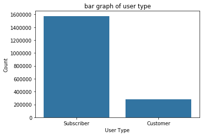

```python
#Plot bar graph of user type to know which user type is more in number.
base_color= sb.color_palette()[0]
sb.countplot(data = df_clean,x='user_type',color = base_color)
plt.title("bar graph of user type")
plt.xlabel('User Type');
plt.ylabel('Count');
```

#### Thus Subscriber uses more number of bikes.

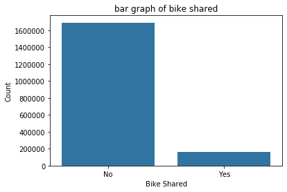

```python
#Plot bar graph of bike shared to know if more no. of people share bike or not.
base_color= sb.color_palette()[0]
sb.countplot(data = df_clean,x='bike_share_for_all_trip',color = base_color)
plt.title("bar graph of bike shared")
plt.xlabel('Bike Shared');
plt.ylabel('Count');
```

#### Maximum no. of bikes are not shared among the people.

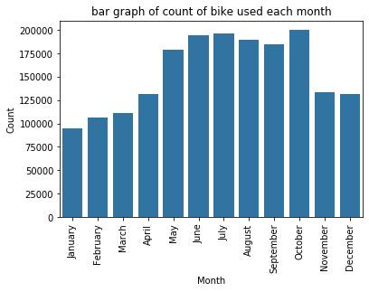

```python
#Plot bar graph of count of bike used each month to know which month show more use of bikes.
base_color= sb.color_palette()[0]
sb.countplot(data = df_clean,x='start_time_month',color = base_color)
plt.title("bar graph of count of bike used each month")
plt.xlabel('Month');
plt.ylabel('Count');
plt.xticks(rotation = 90)
plt.show()
```

#### So in month of October more no. of bkes were used in 2018 year.

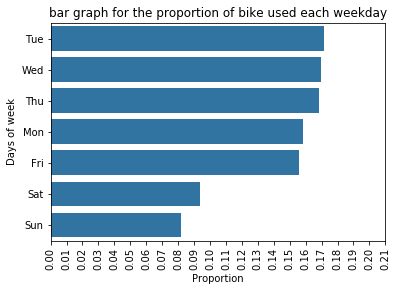

```python
#Plot bar graph for the proportion of bike used each weekday to know which Weekday show more use of bikes.
day_counts =df_clean.start_time_day.value_counts()
day_order = day_counts.index
max_prop=day_counts[0]/len(df_clean)
base_color= sb.color_palette()[0]

tick_props = np.arange(0, max_prop+0.04, 0.01)
tick_names = ['{:0.2f}'.format(v) for v in tick_props]
sb.countplot(data = df_clean,y='start_time_day',color = base_color,order=day_order)
plt.xticks(tick_props * len(df_clean), tick_names)
plt.title("bar graph for the proportion of bike used each weekday")
plt.xlabel('Proportion');
plt.ylabel('Days of week');
plt.xticks(rotation = 90)
plt.show()
```

#### On Tuesday more no. of rides were there. and from Monday to Friday shws more trip as comared to Sat-Sun because Mon-Fri are working days.

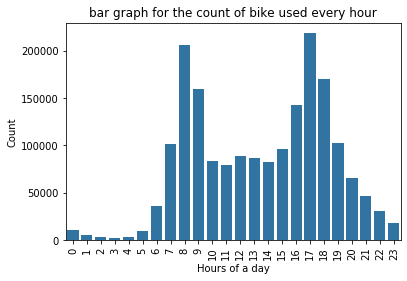

```python
#Plot bar graph of bike used each hour to know which hour show more use of bikes.
base_color= sb.color_palette()[0]
sb.countplot(data = df_clean,x='start_time_hour',color = base_color)
plt.title("bar graph for the count of bike used every hour")
plt.xlabel('Hours of a day');
plt.ylabel('Count');
plt.xticks(rotation = 90)
plt.show()
```

#### There are two time interval in the whole day at which more number of rides were taken i.e. 8-9a.m and 5-6p.m. This is due to the reason that riders went to office and came back during these time interval.

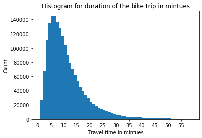

```python
#Plot Histogram for duration of the bike trip in mintues to know more no. of bike were used for how many mintues.
bins = np.arange(1,60,1)
ticks = np.arange(0,60, 5)
plt.hist(data=df_clean,x='duration_min',bins=bins)
plt.xticks(ticks, ticks);
plt.title("Histogram for duration of the bike trip in mintues")
plt.xlabel('Travel time in mintues');
plt.ylabel('Count');
```

#### More number of rides were of 5- 10 minutes.

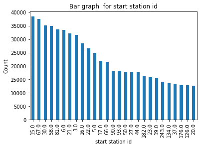

```python
#Plot bar graph for start_station_id to know which start station id has more no. of bike count.
df_clean.start_station_id.value_counts()[:20].plot(kind='bar')
plt.title("Bar graph  for start station id")
plt.xlabel('start station id');
plt.ylabel('Count');
```

#### From start station id 15.0 more number of trips started as depicted in above graph.

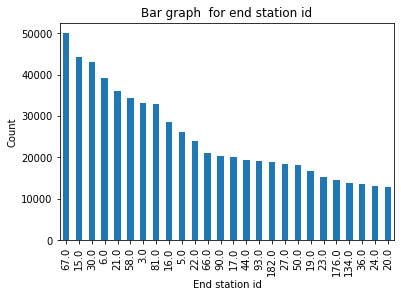

```python
#Plot bar graph for start_station_id to know which end station id has more no. of bike count.
df_clean.end_station_id.value_counts()[:20].plot(kind='bar')
plt.title("Bar graph  for end station id")
plt.xlabel('End station id');
plt.ylabel('Count');
```

#### On End station id 67.0 more no. of trips ended around 50,000.

## Bivariate Exploration

```python
#display the dataset
df_clean.head()
```

|  | duration_sec | start_time | end_time | start_station_id | start_station_name | start_station_latitude | start_station_longitude | end_station_id | end_station_name | end_station_latitude | end_station_longitude | bike_id | user_type | bike_share_for_all_trip | duration_min | start_time_month | start_time_day | start_time_hour |
| --- | --- | --- | --- | --- | --- | --- | --- | --- | --- | --- | --- | --- | --- | --- | --- | --- | --- | --- |
| 0 | 75284 | 2018-01-31 22:52:35.239 | 2018-02-01 19:47:19.824 | 120.0 | Mission Dolores Park | 37.761420 | -122.426435 | 285.0 | Webster St at O'Farrell St | 37.783521 | -122.431158 | 2765 | Subscriber | No | 1254.733333 | January | Wed | 22 |
| 1 | 85422 | 2018-01-31 16:13:34.351 | 2018-02-01 15:57:17.310 | 15.0 | San Francisco Ferry Building (Harry Bridges Pl... | 37.795392 | -122.394203 | 15.0 | San Francisco Ferry Building (Harry Bridges Pl... | 37.795392 | -122.394203 | 2815 | Customer | No | 1423.700000 | January | Wed | 16 |
| 2 | 71576 | 2018-01-31 14:23:55.889 | 2018-02-01 10:16:52.116 | 304.0 | Jackson St at 5th St | 37.348759 | -121.894798 | 296.0 | 5th St at Virginia St | 37.325998 | -121.877120 | 3039 | Customer | No | 1192.933333 | January | Wed | 14 |
| 3 | 61076 | 2018-01-31 14:53:23.562 | 2018-02-01 07:51:20.500 | 75.0 | Market St at Franklin St | 37.773793 | -122.421239 | 47.0 | 4th St at Harrison St | 37.780955 | -122.399749 | 321 | Customer | No | 1017.933333 | January | Wed | 14 |
| 4 | 39966 | 2018-01-31 19:52:24.667 | 2018-02-01 06:58:31.053 | 74.0 | Laguna St at Hayes St | 37.776435 | -122.426244 | 19.0 | Post St at Kearny St | 37.788975 | -122.403452 | 617 | Subscriber | No | 666.100000 | January | Wed | 19 |

```python
#display value count of bike_id field
df_clean.start_station_id.value_counts()
```

```
15.0     38461
67.0     37617
30.0     35092
58.0     34918
81.0     33716
         ...
301.0       93
359.0       91
358.0       52
374.0       25
48.0        11
Name: start_station_id, Length: 331, dtype: int64
```

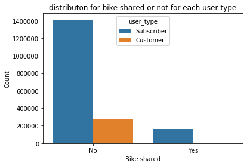

```python
#plot distributon for bike shared or not for each user type.
sb.countplot(data=df_clean,x='bike_share_for_all_trip',hue='user_type')
plt.title("distributon for bike shared or not for each user type")
plt.xlabel('Bike shared');
plt.ylabel('Count');
```

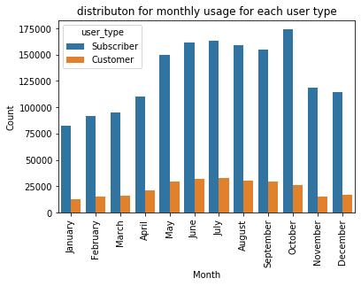

```python
#plot distributon for monthly usage for each user type.
sb.countplot(data=df_clean,x='start_time_month',hue='user_type')
plt.title("distributon for monthly usage for each user type")
plt.xlabel('Month');
plt.ylabel('Count');
plt.xticks(rotation = 90)
plt.show()
```

#### Above graph clearly depicts that count of Subscibers trips is Maximum in month of October ,On the other hand count of Customers trips is Maximum in month of July.

#### In summer seasons i.e from May to October,riders took more number of rides and in te months of winter season count of riders dropped.

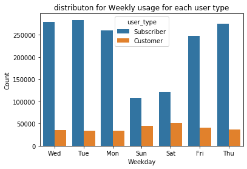

```python
#plot distributon for Weekly usage for each user type.
sb.countplot(data=df_clean,x='start_time_day',hue='user_type')
plt.title("distributon for Weekly usage for each user type")
plt.xlabel('Weekday');
plt.ylabel('Count');
plt.show();
```

#### In case of Subscribers as Monday to Friday is working days that's why count of riders are more from Monday to friday but on weekends i.e. Saturday and sunday, their number dropped to 50%.

#### In case of Customers, situation is reverse as count of riders are more on weekends as compared to weekdays.

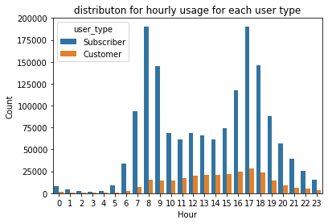

```python
#plot distributon for hourly usage for each user type.
sb.countplot(data=df_clean,x='start_time_hour',hue='user_type')
plt.title("distributon for hourly usage for each user type")
plt.xlabel('Hour');
plt.ylabel('Count');
plt.show();
```

#### In case of Subscribers, more number of rides were taken in the morning around 8 a.m. and in the evening around 5p.m

#### In case of Customers, more number of rides were taken between afternoon and evening period.

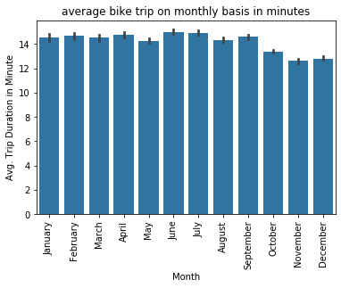

```python
#Plot average bike trip on monthly basis in minutes.
sb.barplot(data=df_clean, x='start_time_month', y='duration_min', color=base_color);
plt.xticks(rotation=90);
plt.title("average bike trip on monthly basis in minutes")
plt.xlabel('Month');
plt.ylabel('Avg. Trip Duration in Minute');
plt.show();
```

#### In month of June and July, the average trip duration is more as compared to other months.

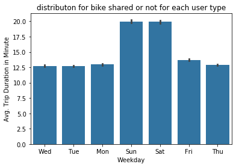

```python
#Plot average bike trip on weekday basis.
sb.barplot(data=df_clean, x='start_time_day', y='duration_min', color=base_color);
plt.title("distributon for bike shared or not for each user type")
plt.xlabel('Weekday');
plt.ylabel('Avg. Trip Duration in Minute');
plt.show();
```

#### On Saturday & Sunday, average trip duration during weekend is more as compared to weekdays

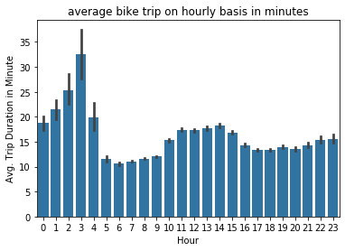

```python
#Plot average bike trip on hourly basis in minutes.
sb.barplot(data=df_clean, x='start_time_hour', y='duration_min', color=base_color);
plt.title("average bike trip on hourly basis in minutes")
plt.xlabel('Hour');
plt.ylabel('Avg. Trip Duration in Minute');
plt.show();
```

#### During the midnight around 3 a.m., the average trip duration is more than 30 min which is the highest throughout the day

## Multivariate Exploration

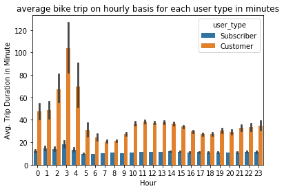

```python
#Plot average bike trip on hourly basis for each user type in minutes.
sb.barplot(data=df_clean, x='start_time_hour', y='duration_min',hue='user_type');
plt.title("average bike trip on hourly basis for each user type in minutes")
plt.xlabel('Hour');
plt.ylabel('Avg. Trip Duration in Minute');
plt.show();
```

#### Hourly Average trip duration is more in case of Customer as compared to Subscribers and it's more than 1 hr at around 3 to 4 a.m which is the highest avg in the whole day.

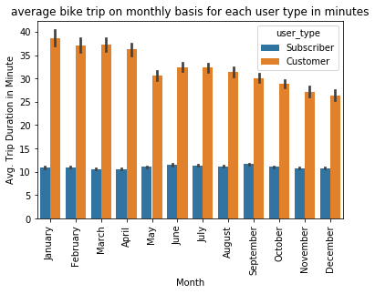

```python
#Plot average bike trip on monthly basis for each user type in minutes.
sb.barplot(data=df_clean, x='start_time_month', y='duration_min',hue='user_type');
plt.xticks(rotation=90);
plt.title("average bike trip on monthly basis for each user type in minutes")
plt.xlabel('Month');
plt.ylabel('Avg. Trip Duration in Minute');
plt.show();
```

#### Monthly Average trip duration is more in case of Customer as compared to Subscribers and in month of January, it's the maximum of around 38 minutes.

#### Subscribes show a consistent average throughout the year.

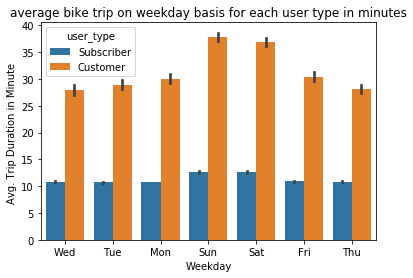

```python
#Plot average bike trip on weekday basis for each user type in minutes.

sb.barplot(data=df_clean, x='start_time_day', y='duration_min',hue='user_type');
plt.title("average bike trip on weekday basis for each user type in minutes")
plt.xlabel('Weekday');
plt.ylabel('Avg. Trip Duration in Minute ');
plt.show();
```

#### For both Subscribers and Customers , avg. trip duration is more on saturday and Sunday as it's weekend.

#### Overall average trip duration of Customers is more than Subscribers.

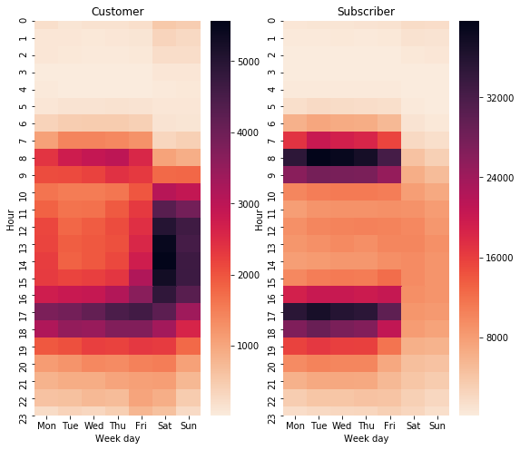

```python
#Plot hourly usage vs weekday for each user type
plt.figure(figsize=(9,8))
df_clean['start_time_day'] = pd.Categorical(df_clean['start_time_day'],
                                                categories=['Mon','Tue','Wed','Thu','Fri','Sat', 'Sun'],
                                                ordered=True)


plt.subplot(1,2,1)
Cust = df_clean.query('user_type in "Customer"').groupby(['start_time_hour', 'start_time_day']).size().reset_index(name='count')
Cust = Cust.pivot("start_time_hour", "start_time_day", "count")
sb.heatmap(Cust, cmap='rocket_r');
plt.title("Customer")
plt.xlabel('Week day');
plt.ylabel('Hour');




plt.subplot(1,2,2)
Cust = df_clean.query('user_type in "Subscriber"').groupby(['start_time_hour', 'start_time_day']).size().reset_index(name='count')
Cust = Cust.pivot("start_time_hour", "start_time_day", "count")
sb.heatmap(Cust, cmap='rocket_r');
plt.title("Subscriber")
plt.xlabel('Week day');
plt.ylabel('Hour');
```

#### Above two heatmaps gives the clear comparison of the rides between Customer and Subscribers which is as follows:

### Customers:

1. Customers travelled more during weekends.
2. Between 3 to 7 p.m. more rides were taken by Customers during weekdays.

### Subscribers:

1. Subscribers travelled very less during weekends.
2. In morning from 8-9a.m and in evening from 5-6 p.m., they use more rides to travel for office and then came back to home in evening.